# Skater Taxonomy - Jim Greco

*Note* Here are some graphs & stats corresponding to the most interesting stuff I found. Let me know if you want me to investigate something else. The graphs aren’t necessarily the best visual representation of the underlying data, so once we hone in on what we want to show, I can export PNGs of the charts so you can trace them in Illustrator/whatever the process for a Jenkem aesthetic is. Also if there’s something you want me to investigate, let me know! I’ll do it so as long as it’s possible with the dataset I created.

## Graphs For Stuff I Said We Should Highlight

- **top tricks are mostly what we expect** (bs 360, switch fs flip variations, etc.)

Important - Given that Greco did a trick down stairs, there’s a 33% chance it was a switch fs flips or nollie bs flips! (not shown in graph, but definitely worth a mention). I.e., 1/3 of Greco’s tricks *down stairs* were switch fs flip variations.

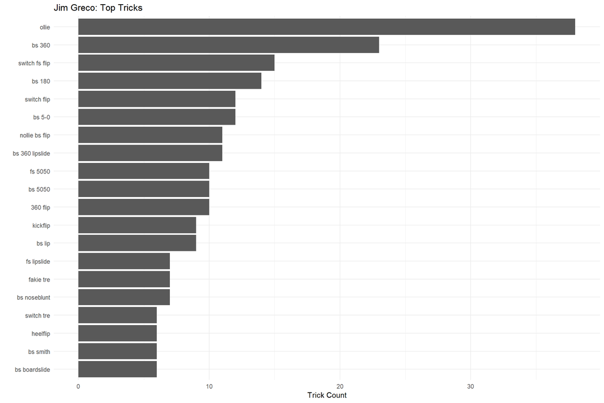

- **top tricks by video part**

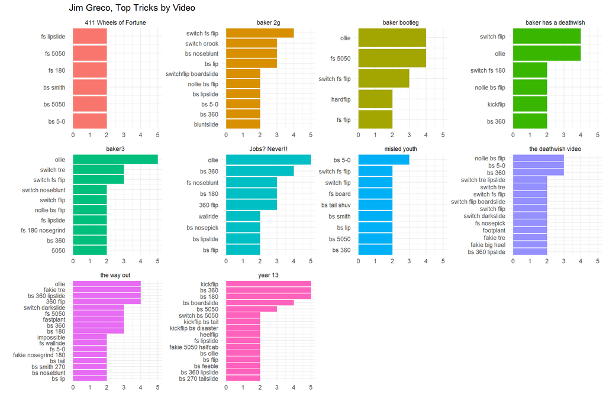

- **Greco loves to skate sloped stuff, and does so a lot (E.g. banks, curbcuts, natural quarterpipes). He did a lot at the beginning of his career, stopped in the middle, and did a lot at the end of his career.**

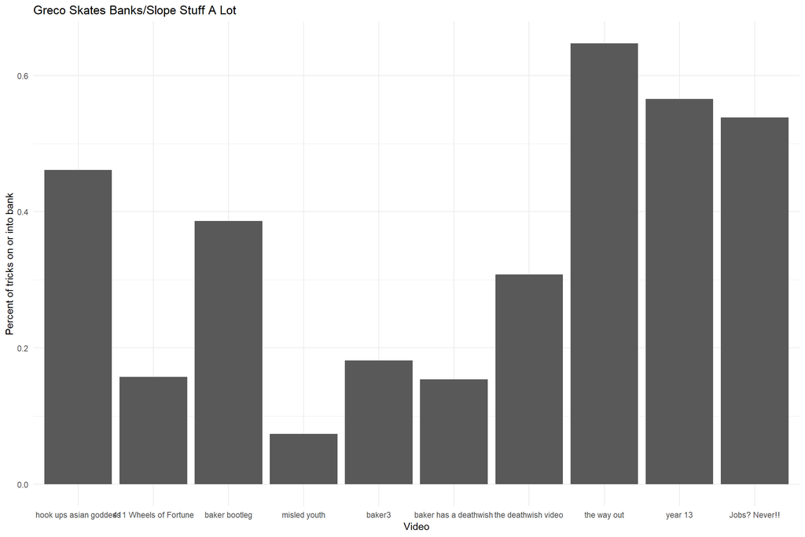

- **Decline of stair + handrail skating over time (Hammers USA was not a lot of hammers).**

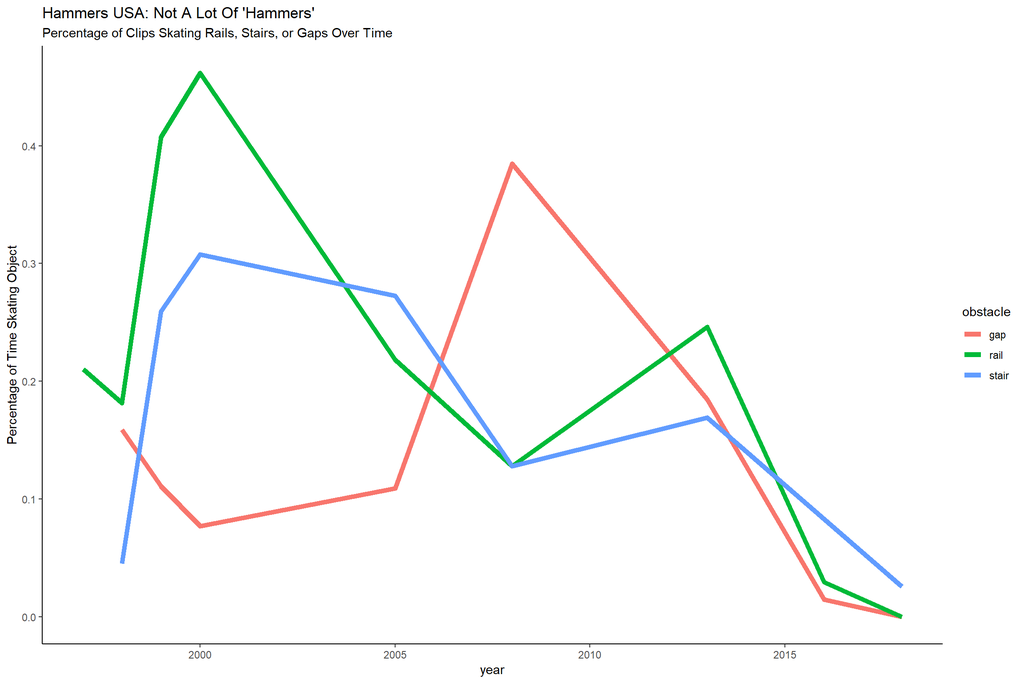

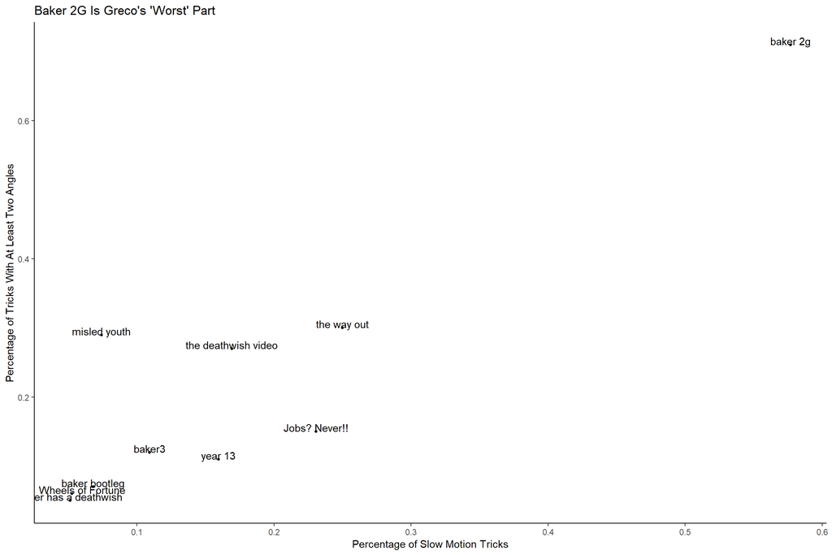

**Sober Greco Is Killing It** - **Greco’s best (traditional) video part in terms of trick diversity + unique trick count: The Deathwish Video.**

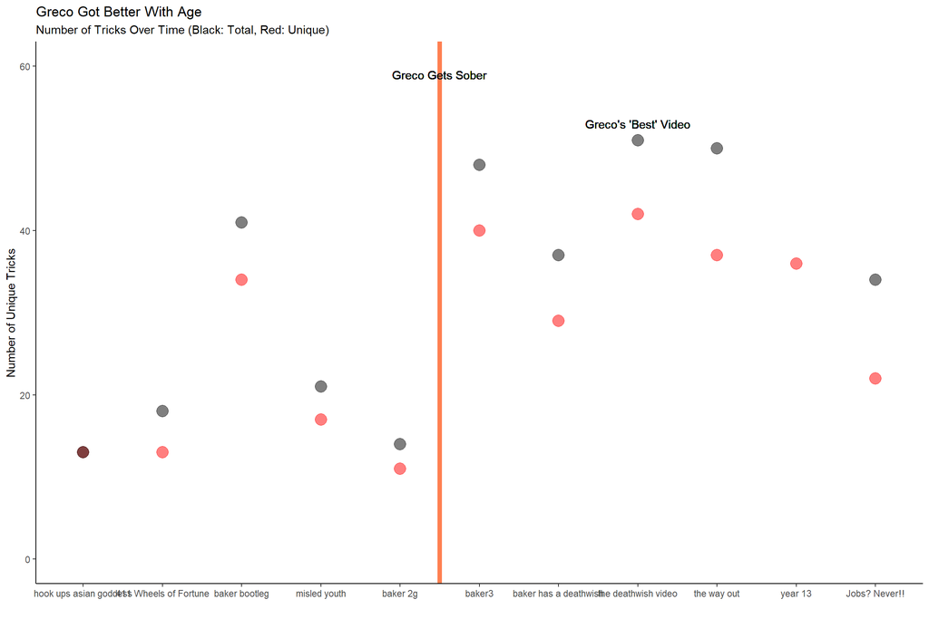

# Summary Stats (just raw numbers)

Total number of clips (including multiple angles): 464.

Total number of tricks across all videos (not counting double-angles): 389.

Number of unique tricks (i.e. don’t count double-angles) where Greco skates a car: 10.

Total number of manual tricks: 7.

Total number of switch clips: 79.

Number of tricks with more than one angle: 69.

Number of flatground tricks: 51.

Number of lines: 40.

Number of tricks in longest line: 4.

Number of tricks involving slopes (i.e. curbcuts, banks, natural quarterpipes, etc.): 138.

Number of slow-mo clips: 77.

## Some Aggregate Stats

Most Popular Tricks

```
## # A tibble: 20 x 2
##    trick             num
##    <chr>           <int>
##  1 ollie              38
##  2 bs 360             23
##  3 switch fs flip     15
##  4 bs 180             14
##  5 bs 5-0             12
##  6 switch flip        12
##  7 bs 360 lipslide    11
##  8 nollie bs flip     11
##  9 360 flip           10
## 10 bs 5050            10
## 11 fs 5050            10
## 12 bs lip              9
## 13 kickflip            9
## 14 bs noseblunt        7
## 15 fakie tre           7
## 16 fs lipslide         7
## 17 bs boardslide       6
## 18 bs smith            6
## 19 heelflip            6
## 20 switch tre          6
```

*Given that a trick is done down stairs, probability of trick being a switch fs flip or nollie bs flip:* 0.3265306. (i.e. P[trick is switch fs flip variation | trick down stairs])

Most popular tricks done on flatground (note, this includes tricks over objects, e.g. a fire hydrant).

```
## # A tibble: 8 x 2
##   trick              n
##   <chr>          <int>
## 1 ollie             10
## 2 bs 180             9
## 3 bs 360             6
## 4 fakie tre          6
## 5 360 flip           5
## 6 hardflip           2
## 7 switch 180         2
## 8 switch fs flip     2
```

Video with most repeated angles

```
## # A tibble: 10 x 2
##    video                 percent_double_angle
##    <chr>                                <dbl>
##  1 baker 2g                             0.71
##  2 the way out                          0.3
##  3 misled youth                         0.290
##  4 the deathwish video                  0.27
##  5 Jobs? Never!!                        0.15
##  6 baker3                               0.12
##  7 year 13                              0.11
##  8 baker bootleg                        0.07
##  9 411 Wheels of Fortune                0.06
## 10 baker has a deathwish                0.05
```

Most popular tricks done in lines

```
## # A tibble: 13 x 2
##    trick                n
##    <chr>            <int>
##  1 ollie               10
##  2 bs 180               9
##  3 bs 360               7
##  4 bs boardslide        4
##  5 switch fs flip       4
##  6 switch bs 5050       3
##  7 bs flip              2
##  8 fakie tre            2
##  9 fs 180 nosegrind     2
## 10 nollie bs flip       2
## 11 nose manual          2
## 12 switch 180           2
## 13 switch flip          2
```

Video with most switch tricks:

```
## # A tibble: 8 x 2
##   video                      n
##   <chr>                  <int>
## 1 baker3                    19
## 2 baker has a deathwish     18
## 3 baker bootleg             12
## 4 the deathwish video       11
## 5 baker 2g                   8
## 6 hook ups asian goddess     6
## 7 misled youth               4
## 8 year 13                    1
```

Video with most percentage of switch tricks:

```
## # A tibble: 8 x 2
##   video                  percentage_switch
##   <chr>                              <dbl>
## 1 baker has a deathwish             0.487
## 2 baker 2g                          0.462
## 3 hook ups asian goddess            0.462
## 4 baker3                            0.4
## 5 baker bootleg                     0.295
## 6 the deathwish video               0.246
## 7 misled youth                      0.185
## 8 year 13                           0.0145
```

Video with most percentage of slow-motion tricks:

```
## # A tibble: 10 x 2
##    video                 percentage_slowmo
##    <chr>                             <dbl>
##  1 baker 2g                         0.577
##  2 the way out                      0.25
##  3 Jobs? Never!!                    0.231
##  4 the deathwish video              0.169
##  5 year 13                          0.159
##  6 baker3                           0.109
##  7 misled youth                     0.0741
##  8 baker bootleg                    0.0682
##  9 411 Wheels of Fortune            0.0526
## 10 baker has a deathwish            0.0513
```

# Bonus: Weirdest Trick?